# Aula 04 Hidrografia

16/09/2021

# Hidrografia

## Recursos hídricos

**97,5%** de toda água na Terra (1,386 trilão de km²) é salgada, enquanto os outros **2,5%** é doce**

```
68,9% - calotas polares; 29,9% - aquíferos; 1% - superfícies acessiveis. A água doce aproveitável representa 0,007%
```

**Brasil possui maior parcela (12%) das fontes renováveis (energia) de **água doce** do mundo (UNESCO)**

```
9 países possuem 60%
```

## Cliclo hidrológico

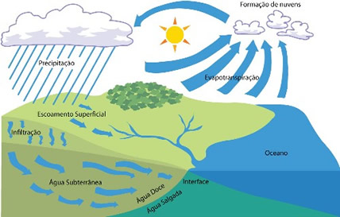

## Águas oceânicas

[figure not shown]

## Águas continentais

### Bacias hidrográficas

Área de captação natural da água que chove e escoa para um único ponto de saída.

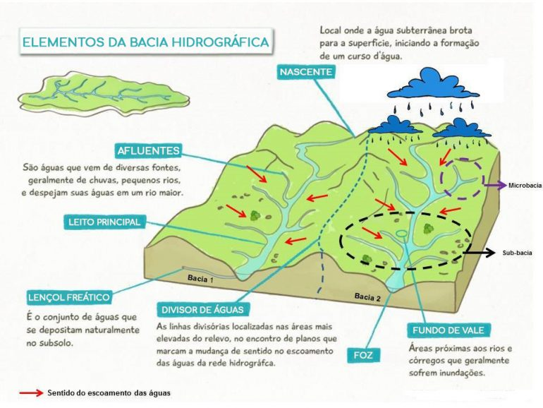

### Bacias hidrográficas brasileiras

[figure not shown]

### Rios

Corrente de água permanete ou não, que leva excesso das águas continentais superficiais até os oceanos, mares e lagos.

[video not shown]

### Lagos

Massas líquidas continentais delimitadas por terrenos ou água acumulada em depressões

### Geleiras (ou glaciais)

Regiões onde a precipitação de neve é superior ao derretimento

### Água subterrânea

Água que ocupa “vazios” em formações rochosas

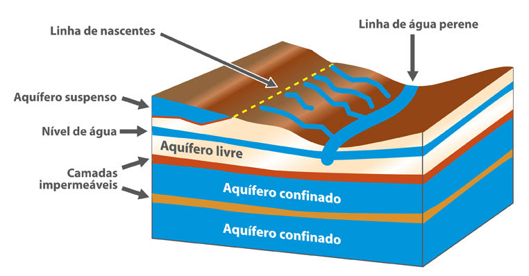

### Aquíferos do Brasil

[figure not shown]

## Poluição

- Contaminação ou colmatação; Acidificação; Alterações hidrológicas
- Assoreamento: acúmulo de sedimentos, lixo e outros materiais no leito dos cursos d’água, levados pela **chuva**, **vento** ou pelo **ser humano**

[video not shown]

[Como os manguezais protegem as áreas costeiras! | Instagram](https://www.instagram.com/p/CTe7hXADsgC/)

## Crise mundial da água

- Causas gerais: seca, poluição e má distribuição
- Consequências: falta traz impactos sociais, econômicos e ambientais

### Uso e distribuição da água no Brasil

[figure not shown]

[figure not shown]

### Exploração dos aquíferos

- É uma alternativa para locais que sofrem com a **falta de água**. Porém, o uso de águas subterrâneas deve ser feito com cuidado, pois pode prejudicar as gerações futuras.
- Além disso, um aquífero pode ser facilmente contaminado por substâncias tóxicas decorrentes de atividades agrícolas, lixões e vazamentos de esgoto, por exemplo.

## Transposição das águas do Rio São Francisco

- Desde o tempo do império, discuti-se a possibilidade da transposição das águas do Rio São Francisco para o **Polígono da Seca**, para solucionar o problema da seca no Nordeste.

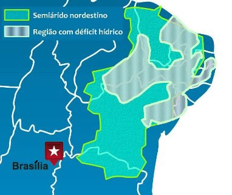